# Incontinence

# 1 Description of DataSchema variable

The description of harmonised variable is the following:

- Short name: `incontinence`
- Variable label: `Incontinence`
- Variable description: `It measures if the participant has experienced loss of urine (or has used any special device for urine leakage) or not.`
- Domain: `Health status and functional limitations`
- Value type: `categorical`
- Category coding:

| **Code** | **Category Label** |
| --- | --- |
| 0 | Yes |
| 1 | No |

- Category missings:

| **Code** | **Category Label** |
| --- | --- |
| 991 | CAPI/interviewer error |
| 992 | Impute |
| 993 | Disable to measure |
| 994 | Not attempt/not done |
| 995 | Does not answer |
| 996 | Not applicable |
| 997 | Refuse |
| 998 | Do not know |
| 999 | Missing |

# 2 Data process

## 2.1 England

### 2.1.1 Wave 1

#### 2.1.1.1 Study-specific variable description

| **Name** | `heinct` |
| --- | --- |
| **Label** | `During the last 12 months, have you lost any amount of urine beyond your control?` |
| **Table name** | `wave_1_core_data_v3` |
| **Categories** | `1 = Yes; 2 = No` |
| **Missings** | `-9 = Refusal; -8 = Don't Know; -1 = Not applicable` |
| **Description** |  |

heinct

| Sample size | Missing values |
| --- | --- |
| 12099 | 203 |

Category

|  | 1 | 2 |
| --- | --- | --- |
| Frequency | 1824.00 | 10072.00 |
| Percentage | 15.08 | 83.25 |

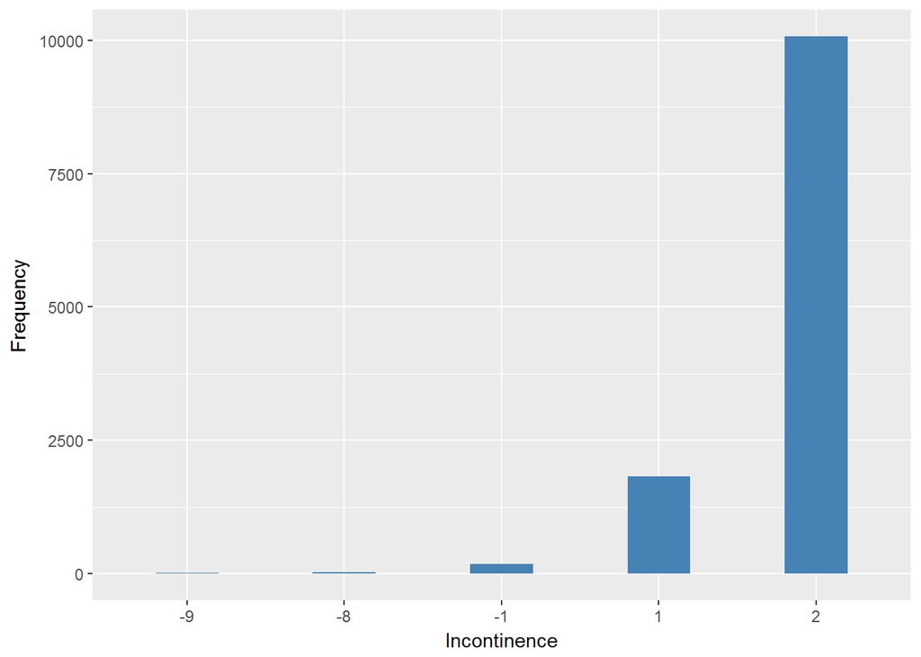

#### 2.1.1.2 Harmonisation algorithm

To compute the harmonize variable from the study-specific variable it has to be recoded as follows:

- `1 into 0`
- `2 into 1`
- `-9 Refusal into 997`
- `-8 Don't know into 998`
- `-1 Not applicable into 996`

**R script:**

```r
ELSA_ds_w1 <- tibble(id = ELSA_w1_incontinence$id)
ELSA_ds_w1$incontinence <- car::recode(ELSA_w1_incontinence$heinct, "1 = '0';2 = '1';-9 = '997';-8 = '998';-1 = '996' ")
ELSA_ds_w1$incontinence <- labelled(ELSA_ds_w1$incontinence, labels = c(Yes = 0,
    No = 1, Missing = 999, Do_not_know = 998, Refuse = 997, Not_applicable = 996,
    Does_not_answer = 995, Not_attempt_not_done = 994, Disable_to_measure = 993,
    Impute = 992, CAPI_interviewer_error = 991))
```

#### 2.1.1.3 Statistical description of the new harmonised variable

incontinence

| Sample size | Missing values |
| --- | --- |
| 12099 | 203 |

Category

|  | 0 | 1 |
| --- | --- | --- |
| Frequency | 1824.00 | 10072.00 |
| Percentage | 15.08 | 83.25 |

Type of missing

|  | 991 | 992 | 993 | 994 | 995 | 996 | 997 | 998 | 999 | NA |
| --- | --- | --- | --- | --- | --- | --- | --- | --- | --- | --- |
| Frequency | 0 | 0 | 0 | 0 | 0 | 175.00 | 9.00 | 19.00 | 0 | 0 |
| Percentage | 0 | 0 | 0 | 0 | 0 | 1.45 | 0.07 | 0.16 | 0 | 0 |

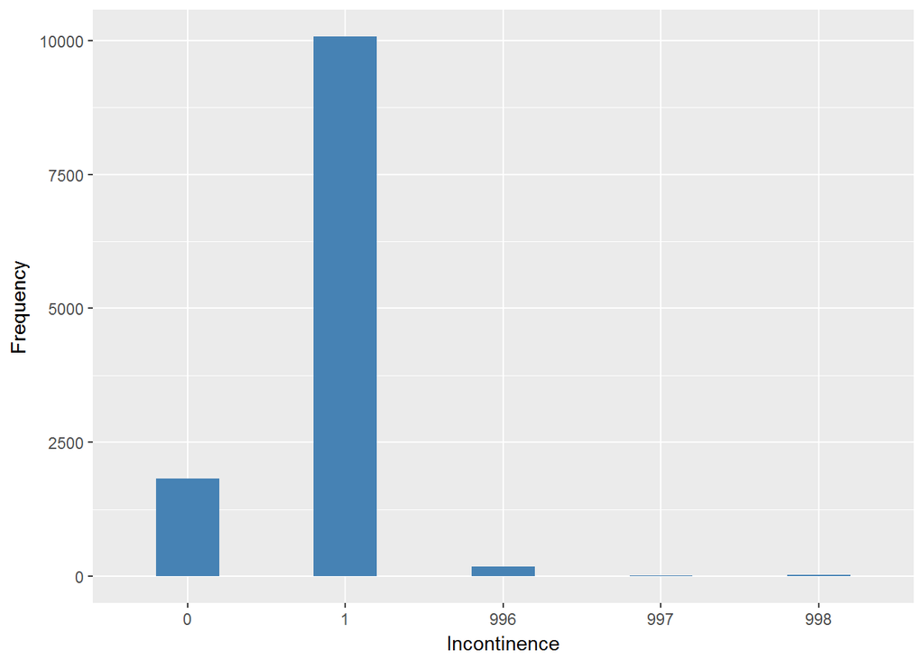

#### 2.1.1.4 Validation

|  | 1->0 | 2->1 | -1->996 | -9->997 | -8->998 |
| --- | --- | --- | --- | --- | --- |
| BeforeH | 1824 | 10072 | 175 | 9 | 19 |
| AfterH | 1824 | 10072 | 175 | 9 | 19 |

### 2.1.2 Wave 2

#### 2.1.2.1 Study-specific variable description

| **Name** | `HeInct` |
| --- | --- |
| **Label** | `Incontinence: whether lost urine beyond control in last 12 months?` |
| **Table name** | `wave_2_core_data_v4` |
| **Categories** | `1 = Yes; 2 = No` |
| **Missings** | `-9 = Refusal; -8 = Don't Know; -1 = Not applicable` |
| **Description** |  |

HeInct

| Sample size | Missing values |
| --- | --- |
| 9432 | 139 |

Category

|  | 1 | 2 |
| --- | --- | --- |
| Frequency | 1368.0 | 7925.00 |
| Percentage | 14.5 | 84.02 |

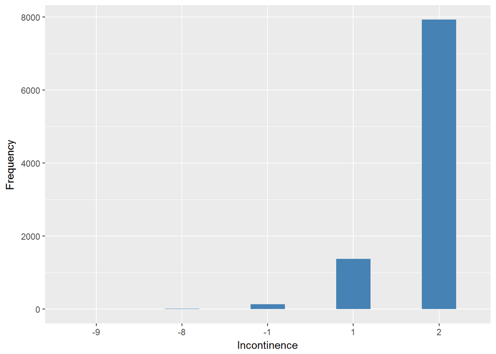

#### 2.1.2.2 Harmonisation algorithm

To compute the harmonize variable from the study-specific variable it has to be recoded as follows:

- `1 into 0`
- `2 into 1`
- `-9 Refusal into 997`
- `-8 Don't know into 998`
- `-1 Not applicable into 996`

**R script:**

```r
ELSA_ds_w2 <- tibble(id = ELSA_w2_incontinence$id)
ELSA_ds_w2$incontinence <- car::recode(ELSA_w2_incontinence$HeInct, "1 = '0';2 = '1';-9 = '997';-8 = '998';-1 = '996' ")
ELSA_ds_w2$incontinence <- labelled(ELSA_ds_w2$incontinence, labels = c(Yes = 0,
    No = 1, Missing = 999, Do_not_know = 998, Refuse = 997, Not_applicable = 996,
    Does_not_answer = 995, Not_attempt_not_done = 994, Disable_to_measure = 993,
    Impute = 992, CAPI_interviewer_error = 991))
```

#### 2.1.2.3 Statistical description of the new harmonised variable

incontinence

| Sample size | Missing values |
| --- | --- |
| 9432 | 139 |

Category

|  | 0 | 1 |
| --- | --- | --- |
| Frequency | 1368.0 | 7925.00 |
| Percentage | 14.5 | 84.02 |

Type of missing

|  | 991 | 992 | 993 | 994 | 995 | 996 | 997 | 998 | 999 | NA |
| --- | --- | --- | --- | --- | --- | --- | --- | --- | --- | --- |
| Frequency | 0 | 0 | 0 | 0 | 0 | 132.0 | 2.00 | 5.00 | 0 | 0 |
| Percentage | 0 | 0 | 0 | 0 | 0 | 1.4 | 0.02 | 0.05 | 0 | 0 |

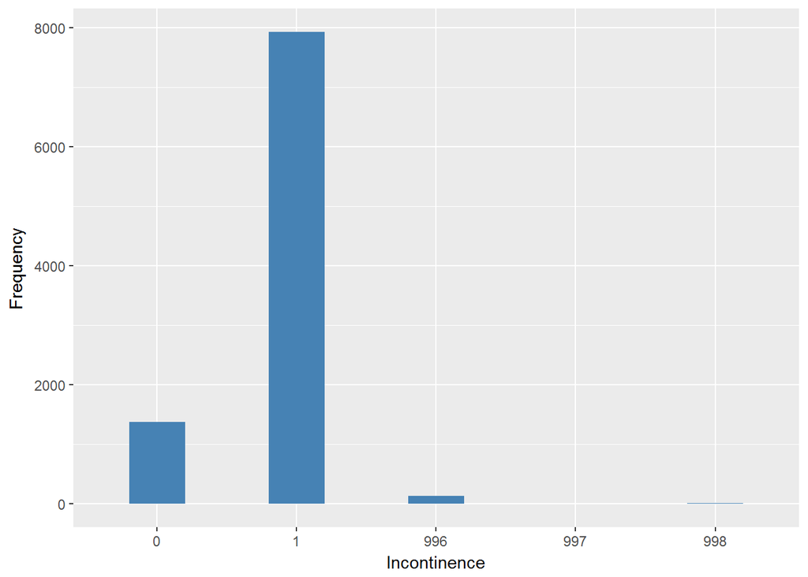

#### 2.1.2.4 Validation

|  | 1->0 | 2->1 | -1->996 | -9->997 | -8->998 |
| --- | --- | --- | --- | --- | --- |
| BeforeH | 1368 | 7925 | 132 | 2 | 5 |
| AfterH | 1368 | 7925 | 132 | 2 | 5 |

### 2.1.3 Wave 3

#### 2.1.3.1 Study-specific variable description

| **Name** | `heinct` |
| --- | --- |
| **Label** | `Incontinence: whether lost urine beyond control in last 12 months?` |
| **Table name** | `wave_3_elsa_data_v4` |
| **Categories** | `1 = Yes; 2 = No` |
| **Missings** | `-9 = Refusal; -8 = Don't Know; -1 = Not applicable` |
| **Description** |  |

heinct

| Sample size | Missing values |
| --- | --- |
| 9771 | 239 |

Category

|  | 1 | 2 |
| --- | --- | --- |
| Frequency | 1308.00 | 8224.00 |
| Percentage | 13.39 | 84.17 |

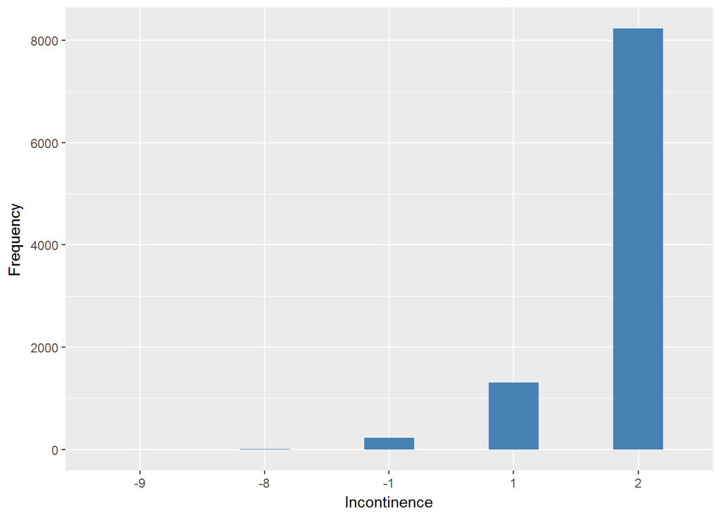

#### 2.1.3.2 Harmonisation algorithm

To compute the harmonize variable from the study-specific variable it has to be recoded as follows:

- `1 into 0`
- `2 into 1`
- `-9 Refusal into 997`
- `-8 Don't know into 998`
- `-1 Not applicable into 996`

**R script:**

```r
ELSA_ds_w3 <- tibble(id = ELSA_w3_incontinence$id)
ELSA_ds_w3$incontinence <- car::recode(ELSA_w3_incontinence$heinct, "1 = '0';2 = '1';-9 = '997';-8 = '998';-1 = '996' ")
ELSA_ds_w3$incontinence <- labelled(ELSA_ds_w3$incontinence, labels = c(Yes = 0,
    No = 1, Missing = 999, Do_not_know = 998, Refuse = 997, Not_applicable = 996,
    Does_not_answer = 995, Not_attempt_not_done = 994, Disable_to_measure = 993,
    Impute = 992, CAPI_interviewer_error = 991))
```

#### 2.1.3.3 Statistical description of the new harmonised variable

incontinence

| Sample size | Missing values |
| --- | --- |
| 9771 | 239 |

Category

|  | 0 | 1 |
| --- | --- | --- |
| Frequency | 1308.00 | 8224.00 |
| Percentage | 13.39 | 84.17 |

Type of missing

|  | 991 | 992 | 993 | 994 | 995 | 996 | 997 | 998 | 999 | NA |
| --- | --- | --- | --- | --- | --- | --- | --- | --- | --- | --- |
| Frequency | 0 | 0 | 0 | 0 | 0 | 232.00 | 2.00 | 5.00 | 0 | 0 |
| Percentage | 0 | 0 | 0 | 0 | 0 | 2.37 | 0.02 | 0.05 | 0 | 0 |

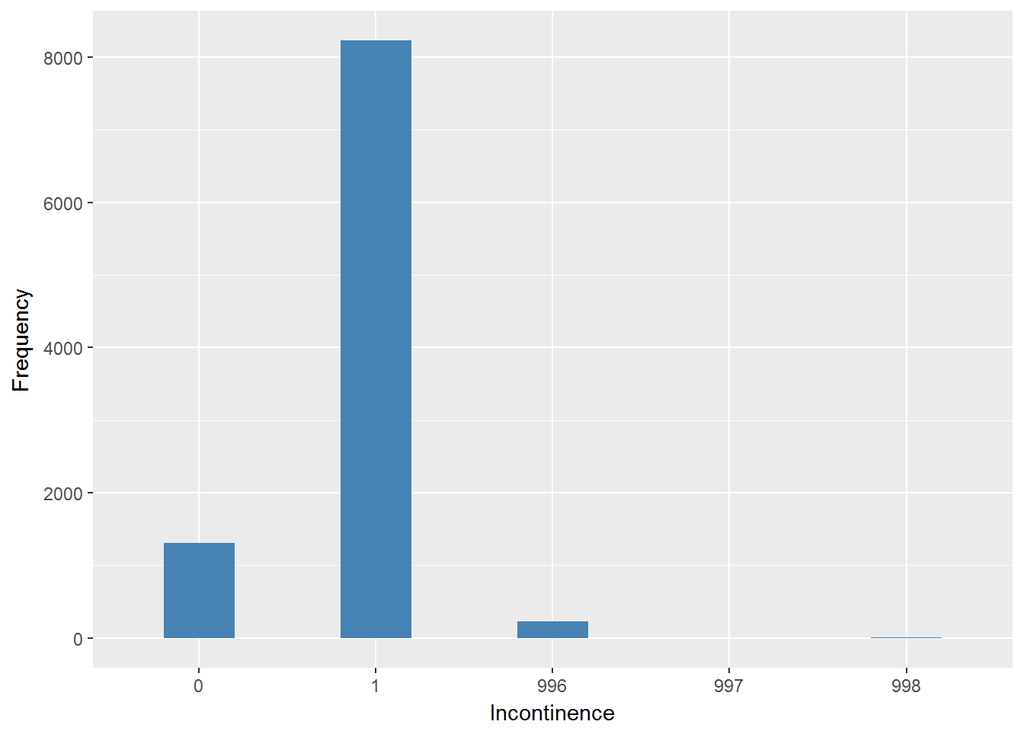

#### 2.1.3.4 Validation

|  | 1->0 | 2->1 | -1->996 | -9->997 | -8->998 |
| --- | --- | --- | --- | --- | --- |
| BeforeH | 1308 | 8224 | 232 | 2 | 5 |
| AfterH | 1308 | 8224 | 232 | 2 | 5 |

### 2.1.4 Wave 4

#### 2.1.4.1 Study-specific variable description

| **Name** | `heinct` |
| --- | --- |
| **Label** | `Incontinence: whether lost urine beyond control in last 12 months?` |
| **Table name** | `wave_4_elsa_data_v3` |
| **Categories** | `1 = Yes; 2 = No` |
| **Missings** | `-9 = Refusal; -8 = Don't Know; -1 = Not applicable` |
| **Description** |  |

heinct

| Sample size | Missing values |
| --- | --- |
| 11050 | 457 |

Category

|  | 1 | 2 |
| --- | --- | --- |
| Frequency | 1550.00 | 9043.00 |
| Percentage | 14.03 | 81.84 |

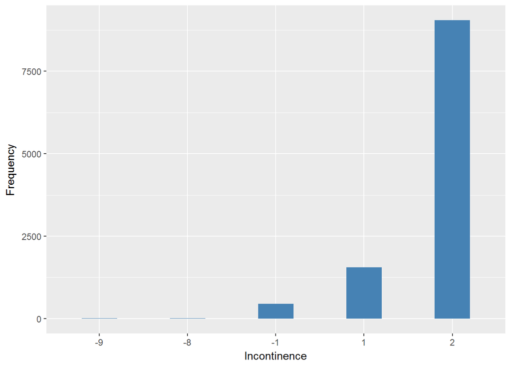

#### 2.1.4.2 Harmonisation algorithm

To compute the harmonize variable from the study-specific variable it has to be recoded as follows:

- `1 into 0`
- `2 into 1`
- `-9 Refusal into 997`
- `-8 Don't know into 998`
- `-1 Not applicable into 996`

**R script:**

```r
ELSA_ds_w4 <- tibble(id = ELSA_w4_incontinence$id)
ELSA_ds_w4$incontinence <- car::recode(ELSA_w4_incontinence$heinct, "1 = '0';2 = '1';-9 = '997';-8 = '998';-1 = '996' ")
ELSA_ds_w4$incontinence <- labelled(ELSA_ds_w4$incontinence, labels = c(Yes = 0,
    No = 1, Missing = 999, Do_not_know = 998, Refuse = 997, Not_applicable = 996,
    Does_not_answer = 995, Not_attempt_not_done = 994, Disable_to_measure = 993,
    Impute = 992, CAPI_interviewer_error = 991))
```

#### 2.1.4.3 Statistical description of the new harmonised variable

incontinence

| Sample size | Missing values |
| --- | --- |
| 11050 | 457 |

Category

|  | 0 | 1 |
| --- | --- | --- |
| Frequency | 1550.00 | 9043.00 |
| Percentage | 14.03 | 81.84 |

Type of missing

|  | 991 | 992 | 993 | 994 | 995 | 996 | 997 | 998 | 999 | NA |
| --- | --- | --- | --- | --- | --- | --- | --- | --- | --- | --- |
| Frequency | 0 | 0 | 0 | 0 | 0 | 446.00 | 6.00 | 5.00 | 0 | 0 |
| Percentage | 0 | 0 | 0 | 0 | 0 | 4.04 | 0.05 | 0.05 | 0 | 0 |

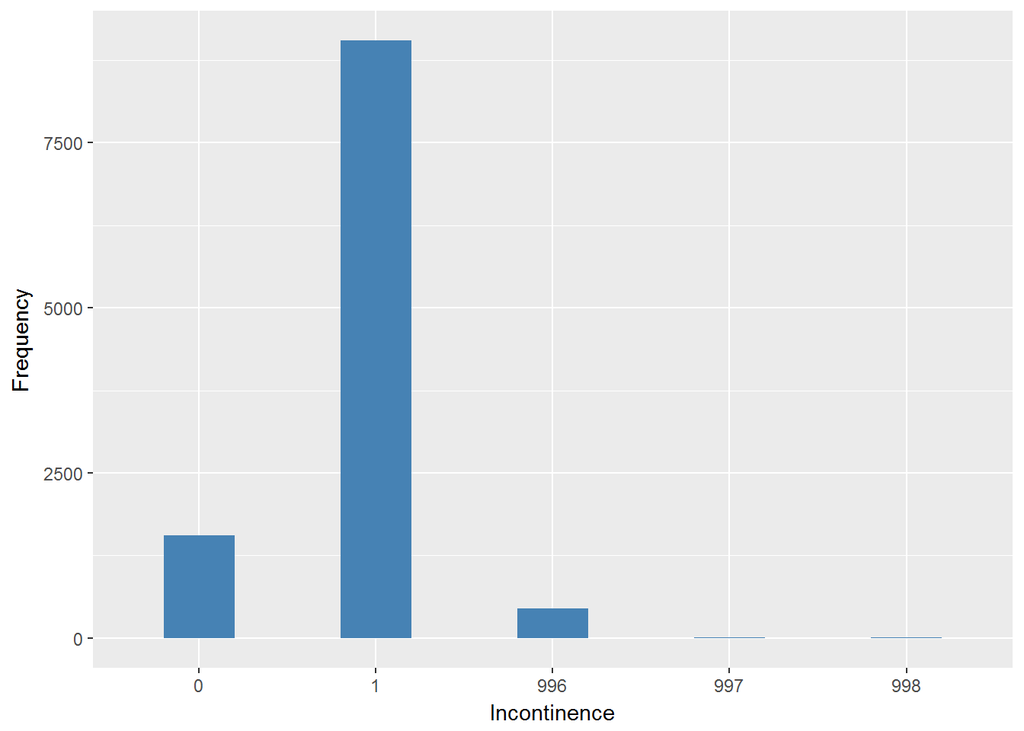

#### 2.1.4.4 Validation

|  | 1->0 | 2->1 | -1->996 | -9->997 | -8->998 |
| --- | --- | --- | --- | --- | --- |
| BeforeH | 1550 | 9043 | 446 | 6 | 5 |
| AfterH | 1550 | 9043 | 446 | 6 | 5 |

### 2.1.5 Wave 5

#### 2.1.5.1 Study-specific variable description

| **Name** | `heinct` |
| --- | --- |
| **Label** | `Incontinence: whether lost urine beyond control in last 12 months?` |
| **Table name** | `wave_5_elsa_data_v4` |
| **Categories** | `1 = Yes; 2 = No` |
| **Missings** | `-9 = Refusal; -8 = Don't Know; -1 = Not applicable` |
| **Description** |  |

heinct

| Sample size | Missing values |
| --- | --- |
| 10274 | 546 |

Category

|  | 1 | 2 |
| --- | --- | --- |
| Frequency | 1448.00 | 8280.00 |
| Percentage | 14.09 | 80.59 |

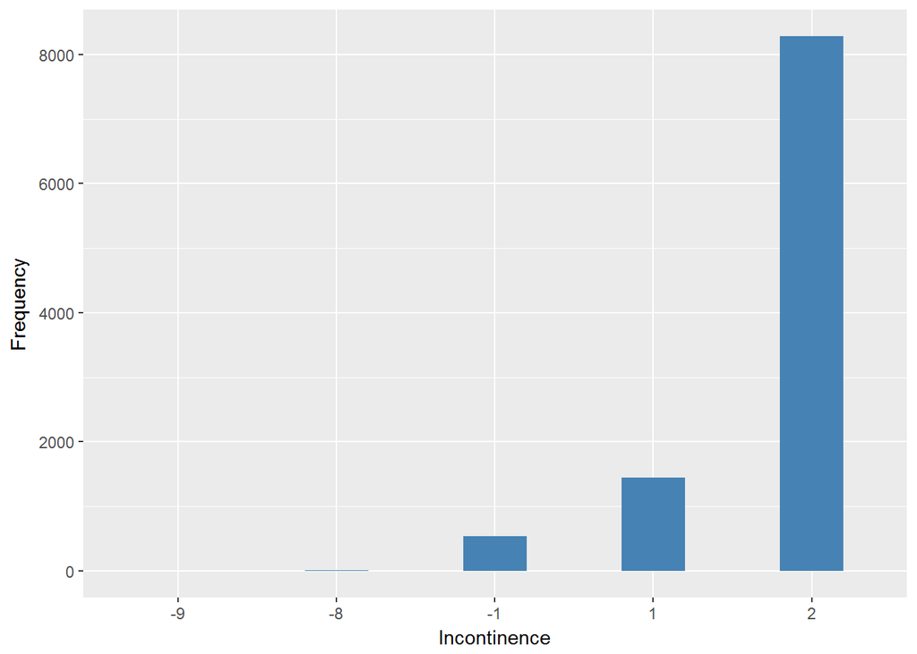

#### 2.1.5.2 Harmonisation algorithm

To compute the harmonize variable from the study-specific variable it has to be recoded as follows:

- `1 into 0`
- `2 into 1`
- `-9 Refusal into 997`
- `-8 Don't know into 998`
- `-1 Not applicable into 996`

**R script:**

```r
ELSA_ds_w5 <- tibble(id = ELSA_w5_incontinence$id)
ELSA_ds_w5$incontinence <- car::recode(ELSA_w5_incontinence$heinct, "1 = '0';2 = '1';-9 = '997';-8 = '998';-1 = '996' ")
ELSA_ds_w5$incontinence <- labelled(ELSA_ds_w5$incontinence, labels = c(Yes = 0,
    No = 1, Missing = 999, Do_not_know = 998, Refuse = 997, Not_applicable = 996,
    Does_not_answer = 995, Not_attempt_not_done = 994, Disable_to_measure = 993,
    Impute = 992, CAPI_interviewer_error = 991))
```

#### 2.1.5.3 Statistical description of the new harmonised variable

incontinence

| Sample size | Missing values |
| --- | --- |
| 10274 | 546 |

Category

|  | 0 | 1 |
| --- | --- | --- |
| Frequency | 1448.00 | 8280.00 |
| Percentage | 14.09 | 80.59 |

Type of missing

|  | 991 | 992 | 993 | 994 | 995 | 996 | 997 | 998 | 999 | NA |
| --- | --- | --- | --- | --- | --- | --- | --- | --- | --- | --- |
| Frequency | 0 | 0 | 0 | 0 | 0 | 537.00 | 4.00 | 5.00 | 0 | 0 |
| Percentage | 0 | 0 | 0 | 0 | 0 | 5.23 | 0.04 | 0.05 | 0 | 0 |

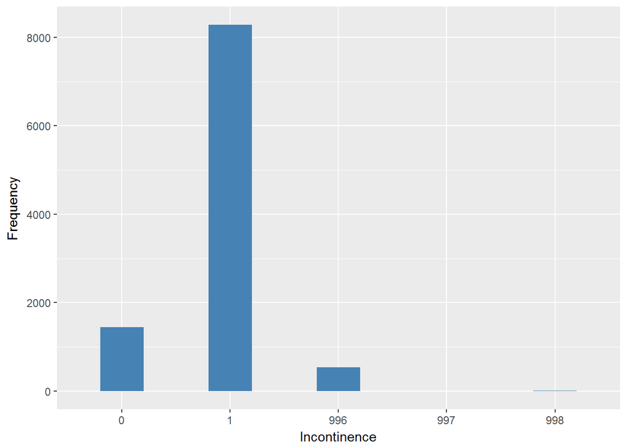

#### 2.1.5.4 Validation

|  | 1->0 | 2->1 | -1->996 | -9->997 | -8->998 |
| --- | --- | --- | --- | --- | --- |
| BeforeH | 1448 | 8280 | 537 | 4 | 5 |
| AfterH | 1448 | 8280 | 537 | 4 | 5 |

### 2.1.6 Wave 6

#### 2.1.6.1 Study-specific variable description

| **Name** | `HeInct` |
| --- | --- |
| **Label** | `Incontinence: whether lost urine beyond control in last 12 months?` |
| **Table name** | `wave_6_elsa_data_v2` |
| **Categories** | `1 = Yes; 2 = No` |
| **Missings** | `-9 = Refusal; -8 = Don't Know; -1 = Not applicable` |
| **Description** |  |

HeInct

| Sample size | Missing values |
| --- | --- |
| 10601 | 624 |

Category

|  | 1 | 2 |
| --- | --- | --- |
| Frequency | 1550.00 | 8427.00 |
| Percentage | 14.62 | 79.49 |

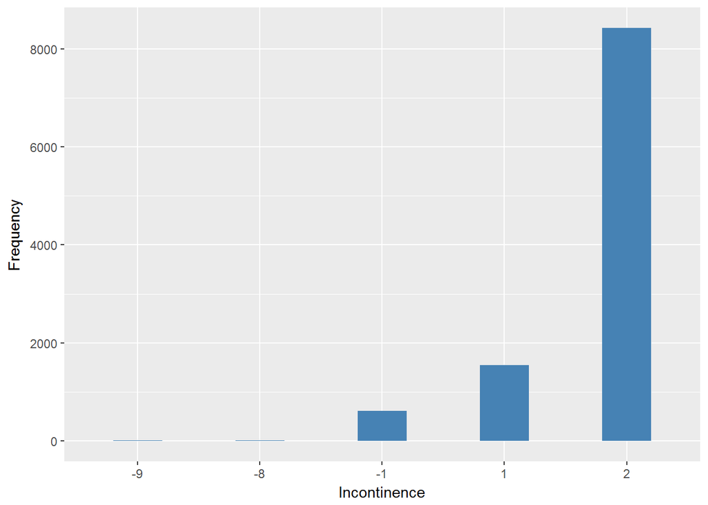

#### 2.1.6.2 Harmonisation algorithm

To compute the harmonize variable from the study-specific variable it has to be recoded as follows:

- `1 into 0`
- `2 into 1`
- `-9 Refusal into 997`
- `-8 Don't know into 998`
- `-1 Not applicable into 996`

**R script:**

```r
ELSA_ds_w6 <- tibble(id = ELSA_w6_incontinence$id)
ELSA_ds_w6$incontinence <- car::recode(ELSA_w6_incontinence$HeInct, "1 = '0';2 = '1';-9 = '997';-8 = '998';-1 = '996' ")
ELSA_ds_w6$incontinence <- labelled(ELSA_ds_w6$incontinence, labels = c(Yes = 0,
    No = 1, Missing = 999, Do_not_know = 998, Refuse = 997, Not_applicable = 996,
    Does_not_answer = 995, Not_attempt_not_done = 994, Disable_to_measure = 993,
    Impute = 992, CAPI_interviewer_error = 991))
```

#### 2.1.6.3 Statistical description of the new harmonised variable

incontinence

| Sample size | Missing values |
| --- | --- |
| 10601 | 624 |

Category

|  | 0 | 1 |
| --- | --- | --- |
| Frequency | 1550.00 | 8427.00 |
| Percentage | 14.62 | 79.49 |

Type of missing

|  | 991 | 992 | 993 | 994 | 995 | 996 | 997 | 998 | 999 | NA |
| --- | --- | --- | --- | --- | --- | --- | --- | --- | --- | --- |
| Frequency | 0 | 0 | 0 | 0 | 0 | 614.00 | 5.00 | 5.00 | 0 | 0 |
| Percentage | 0 | 0 | 0 | 0 | 0 | 5.79 | 0.05 | 0.05 | 0 | 0 |

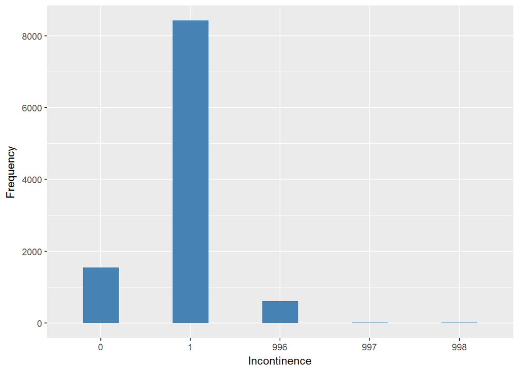

#### 2.1.6.4 Validation

|  | 1->0 | 2->1 | -1->996 | -9->997 | -8->998 |
| --- | --- | --- | --- | --- | --- |
| BeforeH | 1550 | 8427 | 614 | 5 | 5 |
| AfterH | 1550 | 8427 | 614 | 5 | 5 |

### 2.1.7 Wave 7

#### 2.1.7.1 Study-specific variable description

| **Name** | `HeInct` |
| --- | --- |
| **Label** | `Incontinence: whether lost urine beyond control in last 12 months?` |
| **Table name** | `wave_7_elsa_data` |
| **Categories** | `1 = Yes; 2 = No` |
| **Missings** | `-8 = Don't Know; -1 = Not applicable` |
| **Description** |  |

HeInct

| Sample size | Missing values |
| --- | --- |
| 9666 | 601 |

Category

|  | 1 | 2 |
| --- | --- | --- |
| Frequency | 1436.00 | 7629.00 |
| Percentage | 14.86 | 78.93 |

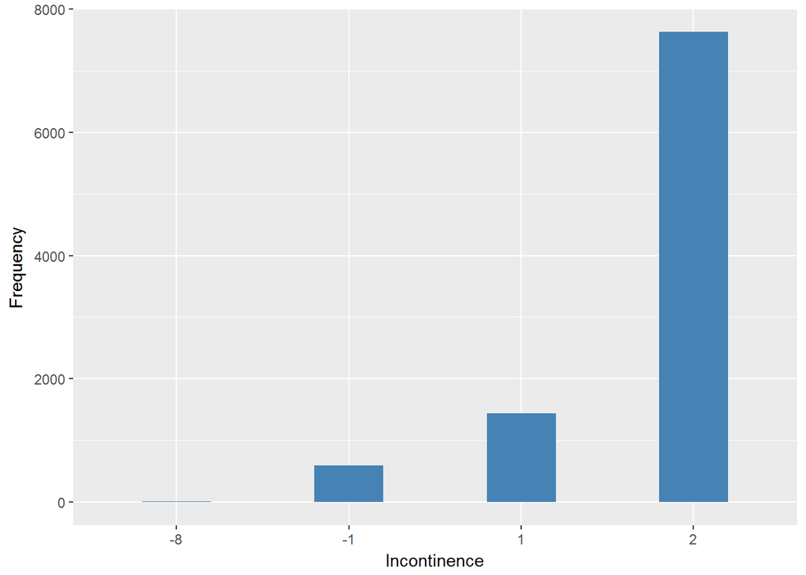

#### 2.1.7.2 Harmonisation algorithm

To compute the harmonize variable from the study-specific variable it has to be recoded as follows:

- `1 into 0`
- `2 into 1`
- `-8 Don't know into 998`
- `-1 Not applicable into 996`

**R script:**

```r
ELSA_ds_w7 <- tibble(id = ELSA_w7_incontinence$id)
ELSA_ds_w7$incontinence <- car::recode(ELSA_w7_incontinence$HeInct, "1 = '0';2 = '1';-9 = '997';-8 = '998';-1 = '996' ")
ELSA_ds_w7$incontinence <- labelled(ELSA_ds_w7$incontinence, labels = c(Yes = 0,
    No = 1, Missing = 999, Do_not_know = 998, Refuse = 997, Not_applicable = 996,
    Does_not_answer = 995, Not_attempt_not_done = 994, Disable_to_measure = 993,
    Impute = 992, CAPI_interviewer_error = 991))
```

#### 2.1.7.3 Statistical description of the new harmonised variable

incontinence

| Sample size | Missing values |
| --- | --- |
| 9666 | 601 |

Category

|  | 0 | 1 |
| --- | --- | --- |
| Frequency | 1436.00 | 7629.00 |
| Percentage | 14.86 | 78.93 |

Type of missing

|  | 991 | 992 | 993 | 994 | 995 | 996 | 997 | 998 | 999 | NA |
| --- | --- | --- | --- | --- | --- | --- | --- | --- | --- | --- |
| Frequency | 0 | 0 | 0 | 0 | 0 | 597.00 | 0 | 4.00 | 0 | 0 |
| Percentage | 0 | 0 | 0 | 0 | 0 | 6.18 | 0 | 0.04 | 0 | 0 |

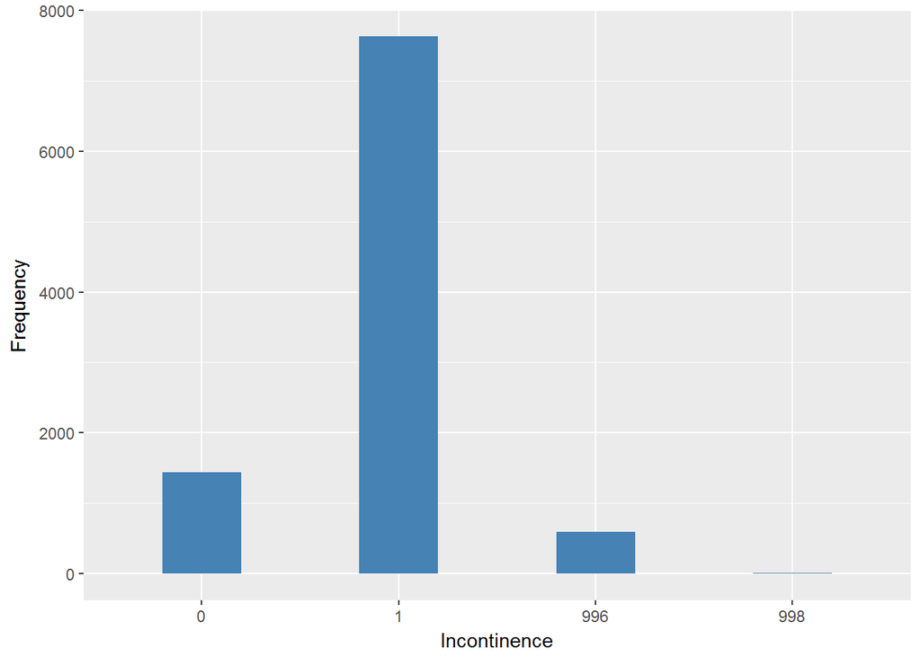

#### 2.1.7.4 Validation

|  | 1->0 | 2->1 | -1->996 | -8->998 |
| --- | --- | --- | --- | --- |
| BeforeH | 1436 | 7629 | 597 | 4 |
| AfterH | 1436 | 7629 | 597 | 4 |

## 2.2 Summary of descriptive statistics of the harmonised variable accross populations and waves

Two tables are generated:

1. Percentages of categories in each harmonised variable.
2. Frequencies and percentages of individuals with different trajectories. To avoid too large table, Only trajectories with percentages larger than 0.3 are shown.

**R script:**

```r
ELSA_ds_w1$incontinence <- labelled(ELSA_ds_w1$incontinence, labels = c(Presence = 0,
    Absence = 1, Missing = 999, Do_not_know = 998, Refuse = 997, Not_applicable = 996,
    Does_not_answer = 995, Not_attempt_not_done = 994, Disable_to_measure = 993,
    Impute = 992, CAPI_interviewer_error = 991))
ELSA_ds_w2$incontinence <- labelled(ELSA_ds_w2$incontinence, labels = c(Presence = 0,
    Absence = 1, Missing = 999, Do_not_know = 998, Refuse = 997, Not_applicable = 996,
    Does_not_answer = 995, Not_attempt_not_done = 994, Disable_to_measure = 993,
    Impute = 992, CAPI_interviewer_error = 991))
ELSA_ds_w3$incontinence <- labelled(ELSA_ds_w3$incontinence, labels = c(Presence = 0,
    Absence = 1, Missing = 999, Do_not_know = 998, Refuse = 997, Not_applicable = 996,
    Does_not_answer = 995, Not_attempt_not_done = 994, Disable_to_measure = 993,
    Impute = 992, CAPI_interviewer_error = 991))
ELSA_ds_w4$incontinence <- labelled(ELSA_ds_w4$incontinence, labels = c(Presence = 0,
    Absence = 1, Missing = 999, Do_not_know = 998, Refuse = 997, Not_applicable = 996,
    Does_not_answer = 995, Not_attempt_not_done = 994, Disable_to_measure = 993,
    Impute = 992, CAPI_interviewer_error = 991))
ELSA_ds_w5$incontinence <- labelled(ELSA_ds_w5$incontinence, labels = c(Presence = 0,
    Absence = 1, Missing = 999, Do_not_know = 998, Refuse = 997, Not_applicable = 996,
    Does_not_answer = 995, Not_attempt_not_done = 994, Disable_to_measure = 993,
    Impute = 992, CAPI_interviewer_error = 991))
ELSA_ds_w6$incontinence <- labelled(ELSA_ds_w6$incontinence, labels = c(Presence = 0,
    Absence = 1, Missing = 999, Do_not_know = 998, Refuse = 997, Not_applicable = 996,
    Does_not_answer = 995, Not_attempt_not_done = 994, Disable_to_measure = 993,
    Impute = 992, CAPI_interviewer_error = 991))
ELSA_ds_w7$incontinence <- labelled(ELSA_ds_w7$incontinence, labels = c(Presence = 0,
    Absence = 1, Missing = 999, Do_not_know = 998, Refuse = 997, Not_applicable = 996,
    Does_not_answer = 995, Not_attempt_not_done = 994, Disable_to_measure = 993,
    Impute = 992, CAPI_interviewer_error = 991))

tt <- frq(ELSA_ds_w1$incontinence)[[1]][, c(1:2, 4)]
tt[4] <- frq(ELSA_ds_w2$incontinence)[[1]][, c(4)]
tt[5] <- frq(ELSA_ds_w3$incontinence)[[1]][, c(4)]
tt[6] <- frq(ELSA_ds_w4$incontinence)[[1]][, c(4)]
tt[7] <- frq(ELSA_ds_w5$incontinence)[[1]][, c(4)]
tt[8] <- frq(ELSA_ds_w6$incontinence)[[1]][, c(4)]
tt[9] <- frq(ELSA_ds_w7$incontinence)[[1]][, c(4)]
tt[13, ] <- c("n", "sample size", length(ELSA_ds_w1$incontinence), length(ELSA_ds_w2$incontinence),
    length(ELSA_ds_w3$incontinence), length(ELSA_ds_w4$incontinence), length(ELSA_ds_w5$incontinence),
    length(ELSA_ds_w6$incontinence), length(ELSA_ds_w7$incontinence))
names(tt) <- c("val", "label", "w1", "w2", "w3", "w4", "w5", "w6", "w7")
kable(tt)
```

| val | label | w1 | w2 | w3 | w4 | w5 | w6 | w7 |
| --- | --- | --- | --- | --- | --- | --- | --- | --- |
| 0 | Presence | 15.08 | 14.5 | 13.39 | 14.03 | 14.09 | 14.62 | 14.86 |
| 1 | Absence | 83.25 | 84.02 | 84.17 | 81.84 | 80.59 | 79.49 | 78.93 |
| 991 | CAPI_interviewer_error | 0 | 0 | 0 | 0 | 0 | 0 | 0 |
| 992 | Impute | 0 | 0 | 0 | 0 | 0 | 0 | 0 |
| 993 | Disable_to_measure | 0 | 0 | 0 | 0 | 0 | 0 | 0 |
| 994 | Not_attempt_not_done | 0 | 0 | 0 | 0 | 0 | 0 | 0 |
| 995 | Does_not_answer | 0 | 0 | 0 | 0 | 0 | 0 | 0 |
| 996 | Not_applicable | 1.45 | 1.4 | 2.37 | 4.04 | 5.23 | 5.79 | 6.18 |
| 997 | Refuse | 0.07 | 0.02 | 0.02 | 0.05 | 0.04 | 0.05 | 0 |
| 998 | Do_not_know | 0.16 | 0.05 | 0.05 | 0.05 | 0.05 | 0.05 | 0.04 |
| 999 | Missing | 0 | 0 | 0 | 0 | 0 | 0 | 0 |
| NA | NA | 0 | 0 | 0 | 0 | 0 | 0 | 0 |
| n | sample size | 12099 | 9432 | 9771 | 11050 | 10274 | 10601 | 9666 |

```r
dbb <- merge(ELSA_m_ds_w1, ELSA_m_ds_w2, by = "id", suffixes = c(".w1", ".w2"),
    all = T)
dbb <- merge(dbb, ELSA_m_ds_w3, by = "id", all = T)
dbb <- merge(dbb, ELSA_m_ds_w4, by = "id", suffixes = c(".w3", ".w4"), all = T)
dbb <- merge(dbb, ELSA_m_ds_w5, by = "id", all = T)
dbb <- merge(dbb, ELSA_m_ds_w6, by = "id", suffixes = c(".w5", ".w6"), all = T)
dbb <- merge(dbb, ELSA_m_ds_w7, by = "id", all = T)
names(dbb) <- c("id", "w1", "w2", "w3", "w4", "w5", "w6", "w7")
v.dbb <- paste(dbb[, 2], dbb[, 3], dbb[, 4], dbb[, 5], dbb[, 6], dbb[, 7], dbb[,
    8], sep = "")
f.dbb <- frq(v.dbb)[[1]][, c(1, 2, 4)]
kable(f.dbb[f.dbb[, 3] >= 0.3, ])
```

|  | val | frq | raw.prc |
| --- | --- | --- | --- |
| 1 | 0000000 | 110 | 0.59 |
| 42 | 000NANANANA | 57 | 0.31 |
| 102 | 00NANANANANA | 114 | 0.62 |
| 166 | 0111111 | 97 | 0.52 |
| 202 | 01NANANANANA | 73 | 0.39 |
| 247 | 0NANANANANANA | 356 | 1.93 |
| 313 | 1011111 | 64 | 0.35 |
| 346 | 10NANANANANA | 96 | 0.52 |
| 388 | 110NANANANA | 69 | 0.37 |
| 413 | 1111011 | 65 | 0.35 |
| 417 | 1111100 | 61 | 0.33 |
| 418 | 1111101 | 80 | 0.43 |
| 420 | 1111110 | 142 | 0.77 |
| 421 | 1111111 | 2574 | 13.92 |
| 422 | 111111NA | 391 | 2.11 |
| 425 | 11111NANA | 307 | 1.66 |
| 434 | 1111NANANA | 409 | 2.21 |
| 446 | 111NA111 | 63 | 0.34 |
| 458 | 111NANANANA | 710 | 3.84 |
| 473 | 11NA1111 | 70 | 0.38 |
| 501 | 11NANANANANA | 1050 | 5.68 |
| 532 | 1NA11111 | 65 | 0.35 |
| 545 | 1NA1NANANANA | 90 | 0.49 |
| 583 | 1NANANANANANA | 1777 | 9.61 |
| 689 | NANA11111 | 622 | 3.36 |
| 690 | NANA1111NA | 94 | 0.51 |
| 693 | NANA111NANA | 80 | 0.43 |
| 700 | NANA11NANANA | 112 | 0.61 |
| 713 | NANA1NANANANA | 308 | 1.67 |
| 714 | NANANA0000 | 58 | 0.31 |
| 750 | NANANA1101 | 55 | 0.30 |
| 752 | NANANA1110 | 63 | 0.34 |
| 753 | NANANA1111 | 1151 | 6.23 |
| 754 | NANANA111NA | 195 | 1.05 |
| 757 | NANANA11NANA | 160 | 0.87 |
| 764 | NANANA1NANANA | 329 | 1.78 |
| 782 | NANANANANA11 | 744 | 4.02 |
| 783 | NANANANANA1NA | 235 | 1.27 |
| 785 | NANANANANANA1 | 433 | 2.34 |
| 786 | NANANANANANANA | 472 | 2.55 |

# 3 Quality estimation

No comments